# Bootstrapping for Campus Climate Findings

ESM 244 - Assignment 4 Task 3

Minnie Ringland

March 8, 2021

#### About the Data

Today, we’ll work with data collected in 2014 about the campus climate experience for individuals of different gender identities on UC sites.

In 2014, the University of California (UC) contracted with Rankin & Associates, Consulting (R&A) to conduct a system-wide “Campus Climate” survey. The purpose of the survey was to gather a wide variety of data related to institutional climate, inclusion, and work-life issues so that the University is better informed about the living and working environments for students, faculty, staff, post-doctoral scholars at the ten UC campuses as well as the Office of the President, the Lawrence Berkeley National Laboratory, and the Division of Agriculture and Natural Resources. Based on the findings, each UC campus and the three locations will develop action plans and strategic initiatives to improve the overall campus climate.

A concerning finding was that 61% of individuals who identify as nonbinary/genderqueer responded that they had personally experienced “exclusionary, offensive, hostile or intimidating conduct.” Since the sample surveyed was so small, we can use bootstrapping, or resampling with replacement, to improve our ability to draw conclusions about the proportion of individuals on campus who experience discriminatory behavior.

#### Create sample data

```r
# Create sample
experience_yes <- rep(1, times = 22)
experience_no <- rep(0, times = 14)
climate_bad <- c(experience_yes, experience_no)
sample <- data.frame("Participant"=1:36, "negative"=climate_bad)
```

#### Create bootstrap samples

```r
# Create a function that will calculate the proportion of each bootstrapped sample
prop_fun <- function (x,i) {sum(x[i])/length(x[i])}

# Get just the vector of conduct
conduct_vec <- sample$negative

set.seed(432)
# Create 10K bootstrap samples with replacement
propboot_10k <- boot(conduct_vec,
                    statistic = prop_fun,
                    R = 10000)

# Also create 100000 bootstrap samples
propboot_100k <- boot(conduct_vec,
                 statistic = prop_fun,
                 R = 100000)
```

#### Plot histogram

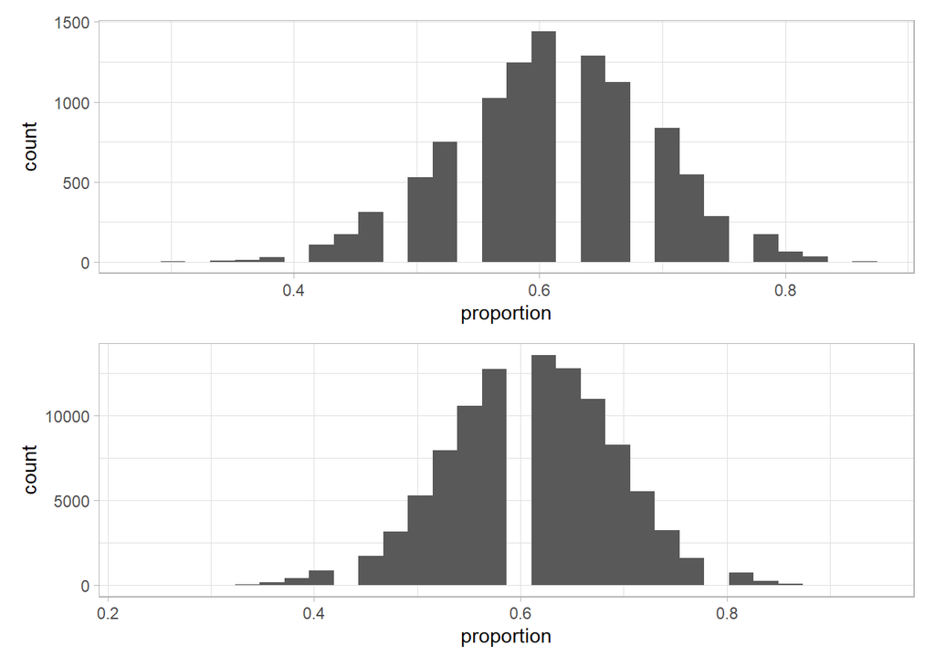

```r
df_10k <-data.frame(proportion = propboot_10k$t)
df_100k <- data.frame(proportion = propboot_100k$t)

# Histogram of 10K sample:
p1 <- ggplot(data = df_10k, aes(x = proportion)) +
  geom_histogram()

# Histogram of 100K sample:
p2 <- ggplot(data = df_100k, aes(x = proportion)) +
  geom_histogram()

(p1 / p2) & theme_light()
```

#### Calculate confidence intervals with `boot.ci()`

```r
boot.ci(propboot_10k, conf = 0.95)
```

```
## BOOTSTRAP CONFIDENCE INTERVAL CALCULATIONS
## Based on 10000 bootstrap replicates
##
## CALL :
## boot.ci(boot.out = propboot_10k, conf = 0.95)
##
## Intervals :
## Level      Normal              Basic
## 95%   ( 0.4521,  0.7701 )   ( 0.4444,  0.7778 )
##
## Level     Percentile            BCa
## 95%   ( 0.4444,  0.7778 )   ( 0.4167,  0.7222 )
## Calculations and Intervals on Original Scale
```

```r
boot.ci(propboot_100k, conf = 0.95)
```

```
## BOOTSTRAP CONFIDENCE INTERVAL CALCULATIONS
## Based on 100000 bootstrap replicates
##
## CALL :
## boot.ci(boot.out = propboot_100k, conf = 0.95)
##
## Intervals :
## Level      Normal              Basic
## 95%   ( 0.4511,  0.7714 )   ( 0.4444,  0.7778 )
##
## Level     Percentile            BCa
## 95%   ( 0.4444,  0.7778 )   ( 0.4167,  0.7500 )
## Calculations and Intervals on Original Scale
```

For a 95% confidence interval, we can expect that 95 of 100 samples will have a proportion of individuals experiencing negative conduct between 0.45 and 0.77. Note that this assumes our original sample is representative of the entire UC population.

*Data Source:*  
014 UCSB Campus Climate Project Final Report (prepared by Rankin & Associates Consulting, available at http://campusclimate.ucop.edu/_common/files/pdf-climate/ucsb-full-report.pdf